# Exploratory Data Analysis

## Iris DataSet

### Author : AmirsamHorriat

#### Exploratory Data Analysis(EDA) is one of the easiest project to do in the field of ML and also pretty usefull for ML learners to get more use to data science.

#### In this project we are using Iris DataSet one of the most popular DataSets.

## Libraries :

## >> pandas

## >> numpy

## >> matplotlib

## >> seaborn

## >> sklearn

## Let's start by importing Libraries

```python
import pandas as pd
import numpy as np
import matplotlib.pyplot as plt
import seaborn as sns
from sklearn.datasets import load_iris
```

## Importing DataSet

```python
iris = load_iris()
df = pd.DataFrame(iris.data , columns = iris.feature_names)
df ['species'] = iris.target
df ['species'] = df['species'].map({0: 'setosa' , 1: 'versicolor' , 2: 'virgincia'})

summary_table = pd.DataFrame({
    'Feature' : df.columns,
    'Data Type' : df.dtypes.values,
    'Non-Null Count' :
df.notnull().sum().values,
    'Unique Values':
[df[col].nunique() for col in df.columns]
})

print('\n Basic DataSet info : ')
print(summary_table)

display(df.head())
```

```
 Basic DataSet info :
             Feature Data Type  Non-Null Count  Unique Values
0  sepal length (cm)   float64             150             35
1   sepal width (cm)   float64             150             23
2  petal length (cm)   float64             150             43
3   petal width (cm)   float64             150             22
4            species    object             150              3
```

|  | sepal length (cm) | sepal width (cm) | petal length (cm) | petal width (cm) | species |
| --- | --- | --- | --- | --- | --- |
| 0 | 5.1 | 3.5 | 1.4 | 0.2 | setosa |
| 1 | 4.9 | 3.0 | 1.4 | 0.2 | setosa |
| 2 | 4.7 | 3.2 | 1.3 | 0.2 | setosa |
| 3 | 4.6 | 3.1 | 1.5 | 0.2 | setosa |
| 4 | 5.0 | 3.6 | 1.4 | 0.2 | setosa |

### After importing DataSet we add some codes to read the dataset clearly. This line of codes allow us to have a better look at our DataSet and understand it more to be more accurate when we want to apply something on our DataSet.

## Visualize the Data by using histogram

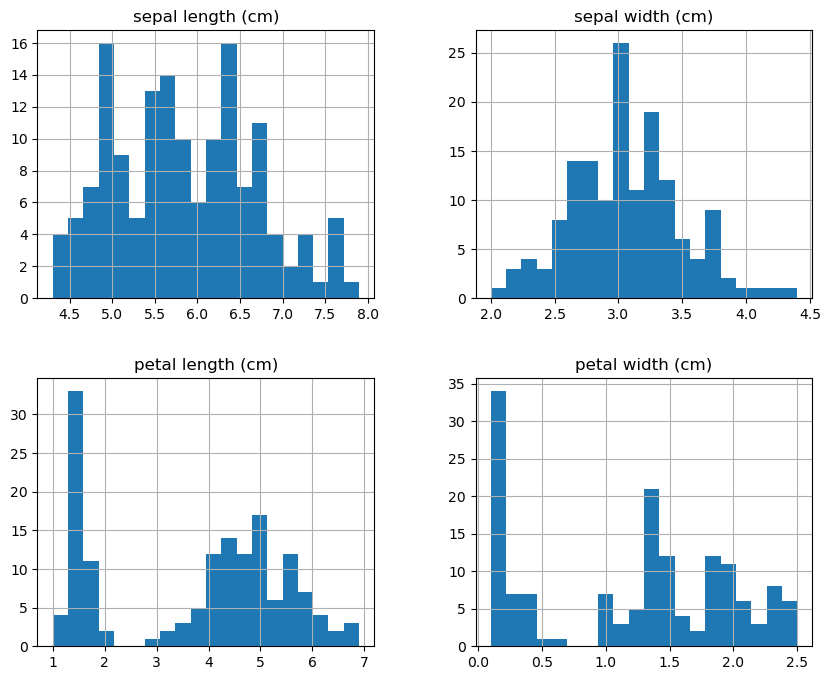

```python
df.hist(figsize = (10,8) , bins = 20)
plt.show()
```

### If you want it be more readable you can do this :

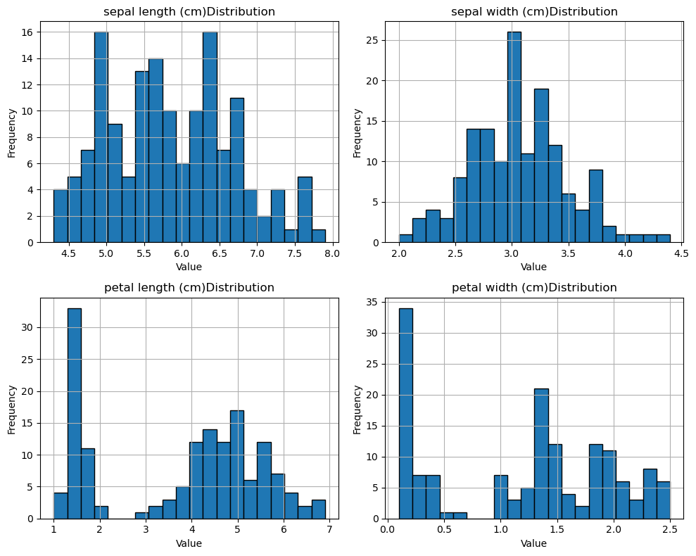

```python
df.hist(figsize=(10, 8) , bins = 20 , edgecolor = 'black')
for ax in plt.gcf().axes:
    ax.set_xlabel('Value')
    ax.set_ylabel('Frequency')
    ax.set_title(ax.get_title() + 'Distribution')

plt.tight_layout()
plt.show()
```

## BoxPlot for identifying the outliers

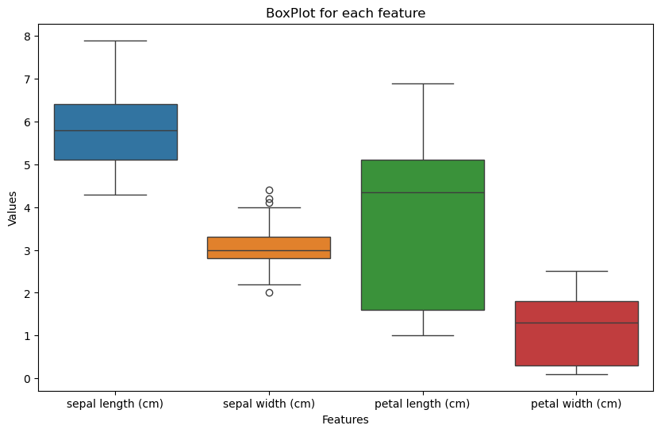

```python
plt.figure(figsize = (10 , 6))
sns.boxplot(data = df.drop(columns = ['species']))
plt.title('BoxPlot for each feature')
plt.xlabel('Features')
plt.ylabel('Values')
plt.show()
```

### Spots that are out of the box are Outlires.

## Correlation Matrix

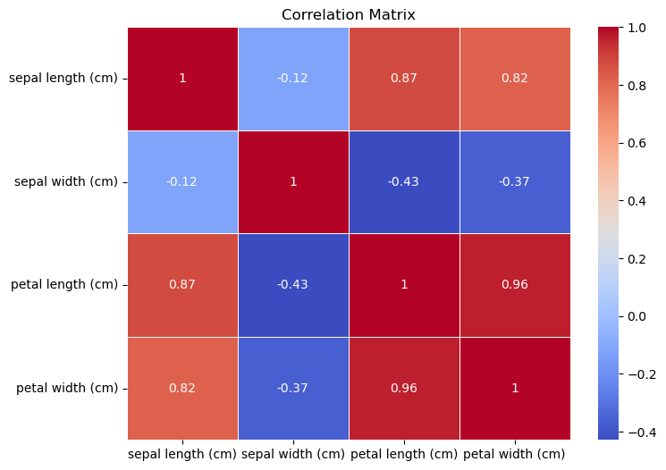

```python
plt.figure(figsize = (8 , 6))
sns.heatmap(df.drop(columns = ['species']).corr() , annot = True , cmap = 'coolwarm' , linewidths = 0.5)
plt.title('Correlation Matrix')
plt.show()
```

#### Numbers close to 1 or 1 are known as strong connection , Numbers close to -1 or -1 are known as strong reverse connection and numbers close to 0 or 0 are known as weak connection or no connection.

#### By the way you can change the color of this chart as example writing downn WINTER instead coolwarm.

## PairPlot , Data Distribution Analysis

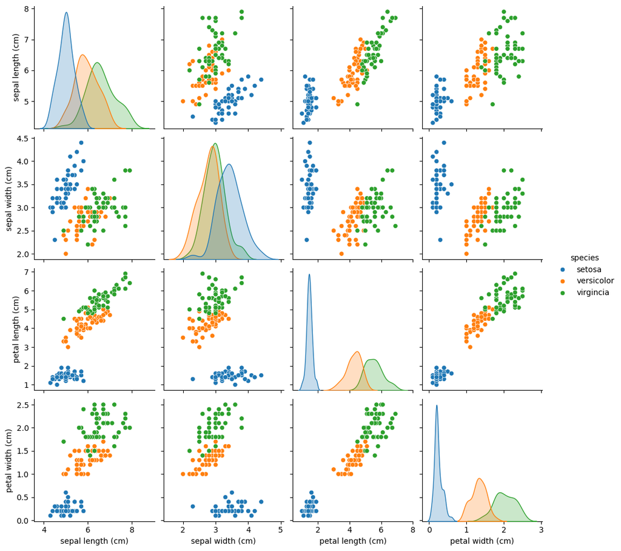

```python
sns.pairplot(df , hue = 'species' ,
diag_kind = 'kde')
plt.show()
```

### Beautiful Visualizing isn't it ? we can use PairPlot to see the connections between features base on species.

## Mean and standard deviation analysis

```python
print(df.groupby('species').mean())
print(df.groupby('species').std())
```

```
            sepal length (cm)  sepal width (cm)  petal length (cm)  \
species
setosa                  5.006             3.428              1.462
versicolor              5.936             2.770              4.260
virgincia               6.588             2.974              5.552

            petal width (cm)
species
setosa                 0.246
versicolor             1.326
virgincia              2.026
            sepal length (cm)  sepal width (cm)  petal length (cm)  \
species
setosa               0.352490          0.379064           0.173664
versicolor           0.516171          0.313798           0.469911
virgincia            0.635880          0.322497           0.551895

            petal width (cm)
species
setosa              0.105386
versicolor          0.197753
virgincia           0.274650
```

#### If mean of one feature has lot diffrent it means that that feature is important for Class

## Visualizing feature distribution across classes

[figure not shown]

```python
plt.figure(figsize = (12,2))
for i , column in enumerate(df.columns[:-1]):
    plt.subplot(2 , 2 , i + 1)
    sns.violinplot(x = 'species' , y = column , data = df)
    plt.title(column)

plt.tight_layout()
plt.show()
```

#### The wider sections of the plot indicate higher data density.

#### If the two classes do not overlap , it means that the given features can help differentiate between the classes.

### After all this analyzings now we can apply a simple model like KNN and test it out let's see

```python
from sklearn.model_selection import train_test_split
from sklearn.preprocessing import StandardScaler
from sklearn.neighbors import KNeighborsClassifier
from sklearn.metrics import accuracy_score , classification_report
```

```python
x = df.drop(columns = ['species'])
y = df['species']
```

```python
x_train , x_test , y_train , y_test = train_test_split(x , y , test_size = 0.2 , random_state = 42 , stratify = y)
```

```python
scaler = StandardScaler()
x_train = scaler.fit_transform(x_train)
x_test = scaler.transform(x_test)
```

```python
knn = KNeighborsClassifier(n_neighbors = 3)
```

```python
knn.fit(x_train , y_train)
```

```
KNeighborsClassifier(n_neighbors=3)
```

```python
y_pred = knn.predict(x_test)
```

```python
accuracy = accuracy_score(y_test , y_pred)
print(f'Model Accuracy : {accuracy:.2f}')
print('\n Classification Report :')
print(classification_report(y_test , y_pred , target_names = iris.target_names))
```

```
Model Accuracy : 0.93

 Classification Report :
              precision    recall  f1-score   support

      setosa       1.00      1.00      1.00        10
  versicolor       0.83      1.00      0.91        10
   virginica       1.00      0.80      0.89        10

    accuracy                           0.93        30
   macro avg       0.94      0.93      0.93        30
weighted avg       0.94      0.93      0.93        30
```

#### So lets take a look at what we just did. . . As i said we used Model Evalution for our model(80% of data for learning , 20% of data for testing) then we trained our model with KNN and we used knn.predict for our model for prediction section.So simple right?

#### The more Accuracy close to 1 the more accurate our model is !

# Tips!

#### Most of the problem with this code while runing , will end up working by "pip installations"

#### you can do more advanced thing with this code by reading documentation of every library

#### Better use Anaconda for this project or projects like this

### Thanks for reading this. this was a simple ML project which i used libraries documentation , stackoverflow , copilot and jadi's tutorials.

### if you have any problem with this code you can email me >> amirsamhorriat09@gmail.com or even more simple just search the problem and let the google or your chosen AI do their magics :)

### Email : amirsamhorriat09@gmail.com

### Linkedin : AmirsamHorriat09

### GitHub : AmirsamHorriat0